# Monitoramento das Funções Orçamentárias

## 1.17 CIÊNCIA E TECNOLOGIA:

**Função:** CIENCIA E TECNOLOGIA

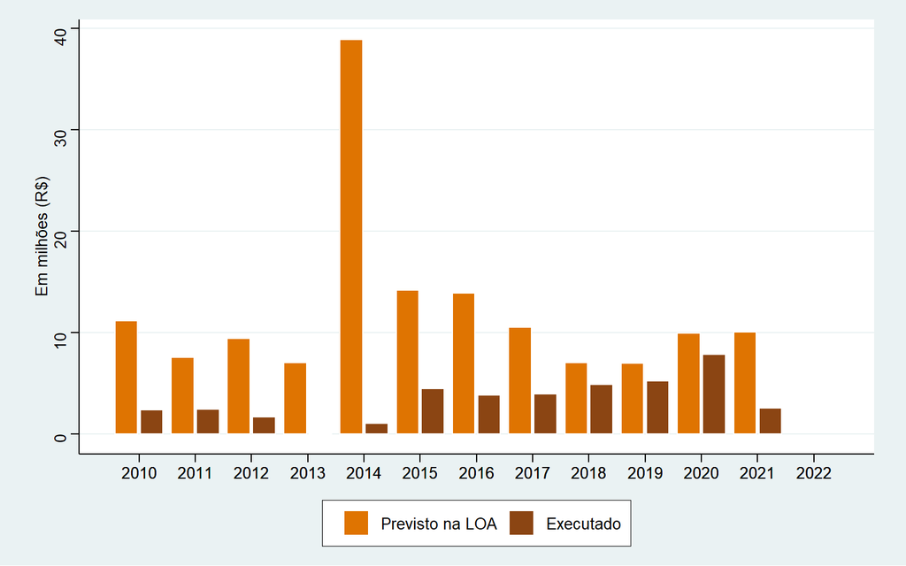

| ANO | PREVISTO NA LOA | EXECUTADO | LOA NOMINAL | EXECUTADO NOMINAL | % EXECUTADO |
| --- | --- | --- | --- | --- | --- |
| 2010 | R$ 11.166.455,77 | R$ 2.426.353,50 | R$ 6.059.750,00 | R$ 1.316.720,00 | 21.73 |
| 2011 | R$ 7.595.679,40 | R$ 2.459.017,38 | R$ 4.365.536,00 | R$ 1.413.294,10 | 32.37 |
| 2012 | R$ 9.449.534,71 | R$ 1.706.128,91 | R$ 5.784.218,00 | R$ 1.044.350,00 | 18.06 |
| 2013 | R$ 7.027.586,40 | R$ 138.302,40 | R$ 4.552.862,00 | R$ 89.600,00 | 1.97 |
| 2014 | R$ 38.939.097,61 | R$ 1.070.262,99 | R$ 26.718.000,00 | R$ 734.359,25 | 2.75 |
| 2015 | R$ 14.175.884,51 | R$ 4.485.450,42 | R$ 10.350.000,00 | R$ 3.274.886,43 | 31.64 |
| 2016 | R$ 13.908.816,24 | R$ 3.825.912,42 | R$ 11.238.857,00 | R$ 3.091.483,98 | 27.51 |
| 2017 | R$ 10.551.441,04 | R$ 3.940.319,65 | R$ 9.062.081,00 | R$ 3.384.134,52 | 37.34 |
| 2018 | R$ 7.035.797,74 | R$ 4.900.776,19 | R$ 6.220.782,00 | R$ 4.333.077,98 | 69.65 |
| 2019 | R$ 6.995.962,04 | R$ 5.276.148,58 | R$ 6.417.246,00 | R$ 4.839.697,98 | 75.42 |
| 2020 | R$ 9.962.405,41 | R$ 7.888.373,00 | R$ 9.531.810,00 | R$ 7.547.421,49 | 79.18 |
| 2021 | R$ 10.085.569,00 | R$ 2.549.688,74 | R$ 10.085.569,00 | R$ 2.549.688,74 | 25.28 |

**Valor previsto no PPA para 2022:** R$ 9.423.758,00

**Percentual de gasto em relação ao total das despesas:**

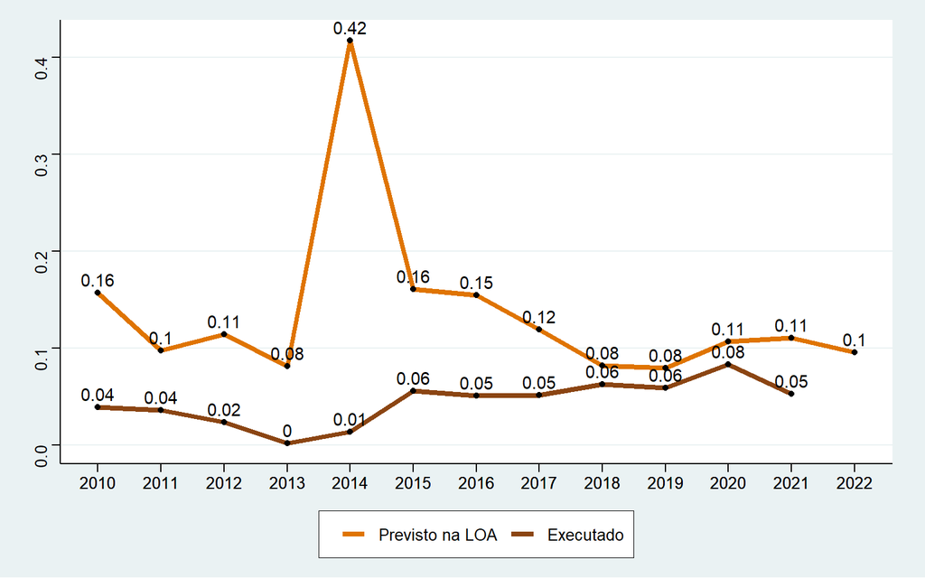

## 1.18 COMÉRCIO E SERVIÇOS:

**Função:** COMERCIO E SERVICOS

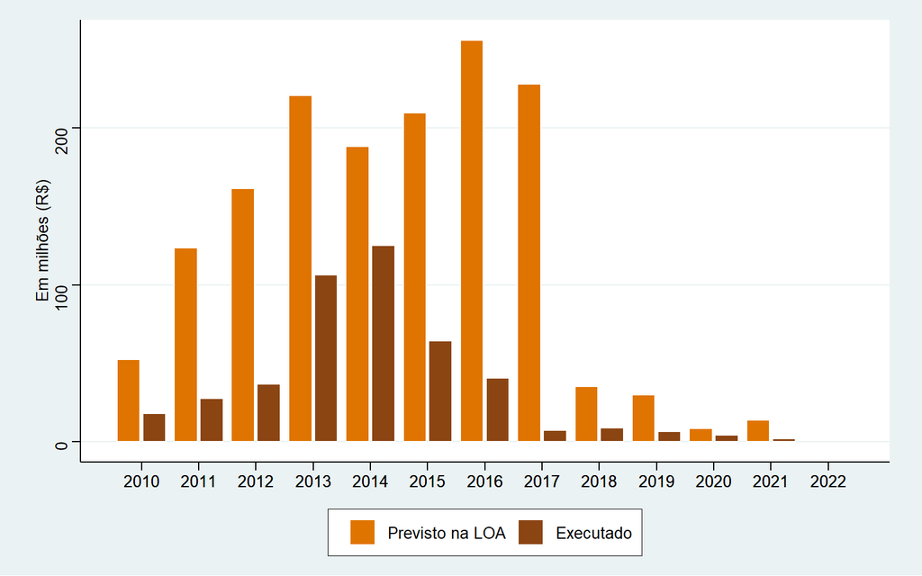

| ANO | PREVISTO NA LOA | EXECUTADO | LOA NOMINAL | EXECUTADO NOMINAL | % EXECUTADO |
| --- | --- | --- | --- | --- | --- |
| 2010 | R$ 52.545.343,04 | R$ 18.092.870,87 | R$ 28.515.014,00 | R$ 9.818.538,36 | 34.43 |
| 2011 | R$ 123.723.725,16 | R$ 27.446.183,79 | R$ 71.108.896,00 | R$ 15.774.402,41 | 22.18 |
| 2012 | R$ 161.407.060,16 | R$ 36.865.600,83 | R$ 98.799.957,00 | R$ 22.566.049,92 | 22.84 |
| 2013 | R$ 220.854.516,05 | R$ 106.394.562,82 | R$ 143.081.860,00 | R$ 68.928.325,37 | 48.17 |
| 2014 | R$ 188.413.229,09 | R$ 125.044.176,57 | R$ 129.279.438,00 | R$ 85.798.863,22 | 66.37 |
| 2015 | R$ 209.834.348,96 | R$ 64.404.047,59 | R$ 153.202.822,00 | R$ 47.022.243,44 | 30.69 |
| 2016 | R$ 256.125.244,00 | R$ 40.725.917,41 | R$ 206.959.021,00 | R$ 32.908.103,34 | 15.90 |
| 2017 | R$ 228.024.228,53 | R$ 7.433.800,00 | R$ 195.838.087,00 | R$ 6.384.502,12 | 3.26 |
| 2018 | R$ 35.302.277,28 | R$ 8.822.480,83 | R$ 31.212.917,00 | R$ 7.800.498,53 | 24.99 |
| 2019 | R$ 30.019.595,07 | R$ 6.655.197,70 | R$ 27.536.331,00 | R$ 6.104.670,18 | 22.17 |
| 2020 | R$ 8.405.158,01 | R$ 4.176.207,66 | R$ 8.041.870,00 | R$ 3.995.703,48 | 49.69 |
| 2021 | R$ 13.772.775,00 | R$ 1.967.039,37 | R$ 13.772.775,00 | R$ 1.967.039,37 | 14.28 |

**Valor previsto no PPA para 2022:** R$ 4.489.490,00

**Percentual de gasto em relação ao total das despesas:**

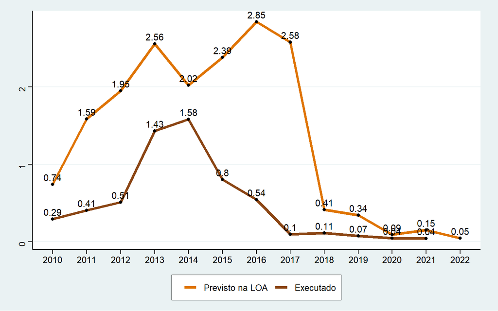

## 1.19 COMUNICAÇÕES:

**Função:** COMUNICACOES

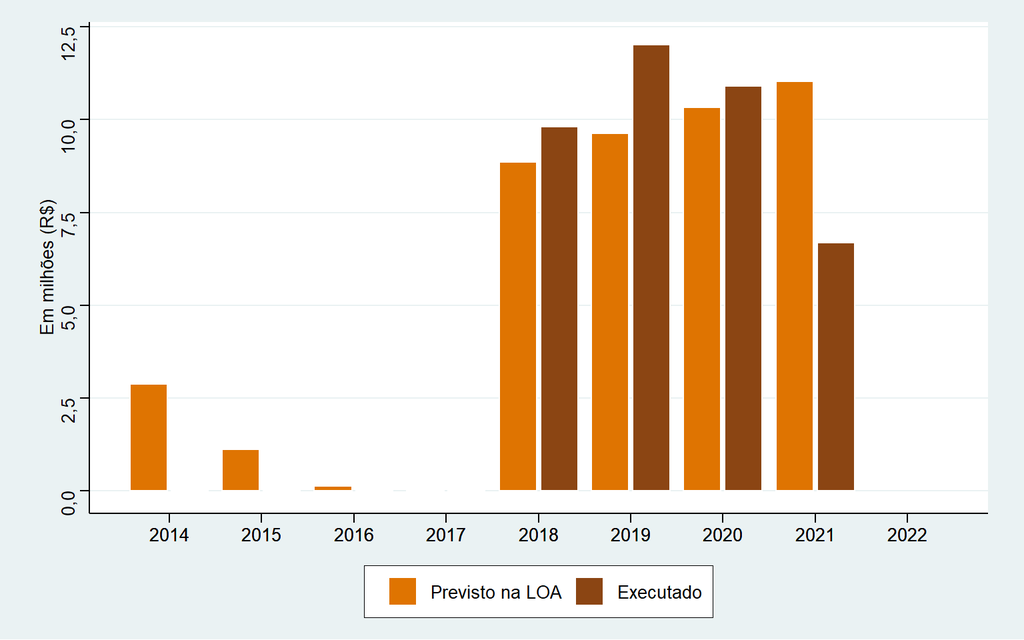

| ANO | PREVISTO NA LOA | EXECUTADO | LOA NOMINAL | EXECUTADO NOMINAL | % EXECUTADO |
| --- | --- | --- | --- | --- | --- |
| 2014 | R$ 2.878.386,02 | R$ 0,00 | R$ 1.975.000,00 | R$ 0,00 | 0.00 |
| 2015 | R$ 1.109.417,05 | R$ 0,00 | R$ 810.000,00 | R$ 0,00 | 0.00 |
| 2016 | R$ 136.132,15 | R$ 0,00 | R$ 110.000,00 | R$ 0,00 | 0.00 |
| 2017 | R$ 23.287,02 | R$ 0,00 | R$ 20.000,00 | R$ 0,00 | 0.00 |
| 2018 | R$ 8.859.170,36 | R$ 9.808.444,82 | R$ 7.832.938,00 | R$ 8.672.250,00 | 110.72 |
| 2019 | R$ 9.623.576,05 | R$ 12.027.412,43 | R$ 8.827.500,00 | R$ 11.032.487,58 | 124.98 |
| 2020 | R$ 10.325.279,57 | R$ 10.910.992,97 | R$ 9.879.000,00 | R$ 10.439.397,68 | 105.67 |
| 2021 | R$ 11.037.500,00 | R$ 6.678.072,48 | R$ 11.037.500,00 | R$ 6.678.072,48 | 60.50 |

**Valor previsto no PPA para 2022:** R$ 16.442.251,00

**Percentual de gasto em relação ao total das despesas:**

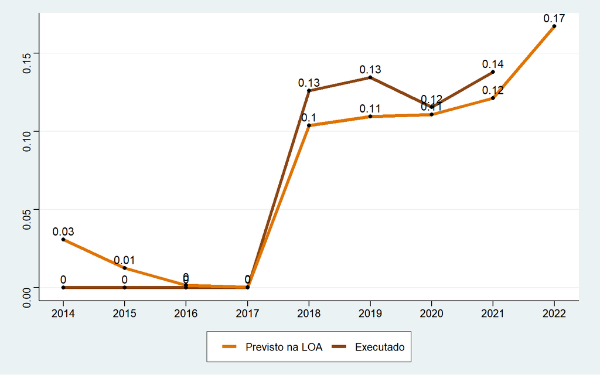

## 1.20 ENERGIA:

**Função:** ENERGIA

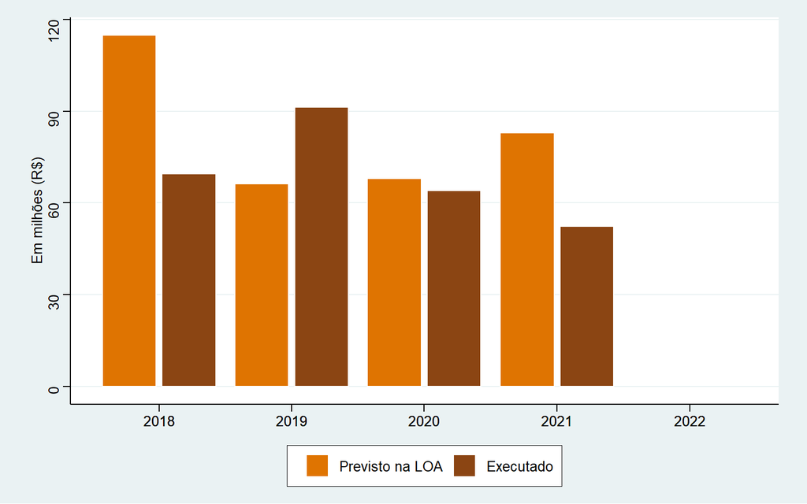

| ANO | PREVISTO NA LOA | EXECUTADO | LOA NOMINAL | EXECUTADO NOMINAL | % EXECUTADO |
| --- | --- | --- | --- | --- | --- |
| 2018 | R$ 114.870.848,41 | R$ 69.518.612,04 | R$ 101.564.390,00 | R$ 61.465.685,36 | 60.52 |
| 2019 | R$ 66.314.480,15 | R$ 91.276.129,35 | R$ 60.828.851,00 | R$ 83.725.636,69 | 137.64 |
| 2020 | R$ 67.940.527,67 | R$ 63.965.728,79 | R$ 65.004.000,00 | R$ 61.201.000,00 | 94.15 |
| 2021 | R$ 82.940.000,00 | R$ 52.338.383,01 | R$ 82.940.000,00 | R$ 52.338.383,01 | 63.10 |

**Valor previsto no PPA para 2022:** R$ 87.950.212,00

**Percentual de gasto em relação ao total das despesas:**

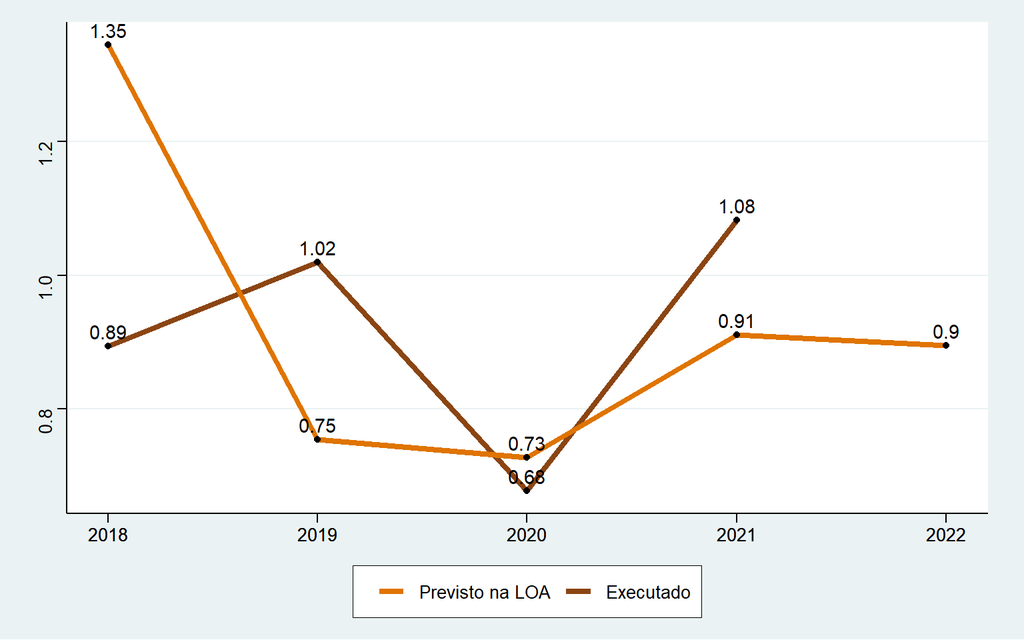

## 1.21 TRANSPORTE:

**Função:** TRANSPORTE

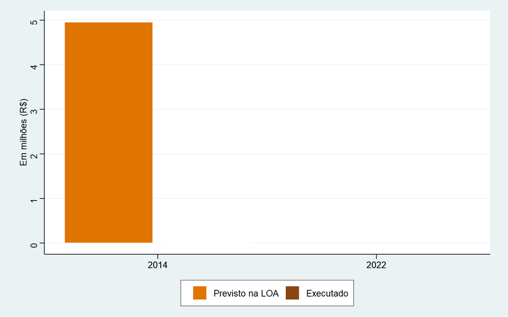

| ANO | PREVISTO NA LOA | EXECUTADO | LOA NOMINAL | EXECUTADO NOMINAL | % EXECUTADO |
| --- | --- | --- | --- | --- | --- |
| 2014 | R$ 4.955.196,19 | R$ 0,00 | R$ 3.400.000,00 | R$ 0,00 | 0 |

**Valor previsto no PPA para 2022:** R$ 100.170.000,00

**Percentual de gasto em relação ao total das despesas:**

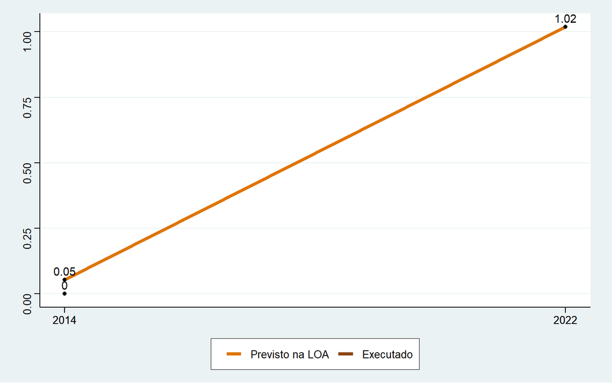

## 1.22 DESPORTO E LAZER:

**Função:** DESPORTO E LAZER

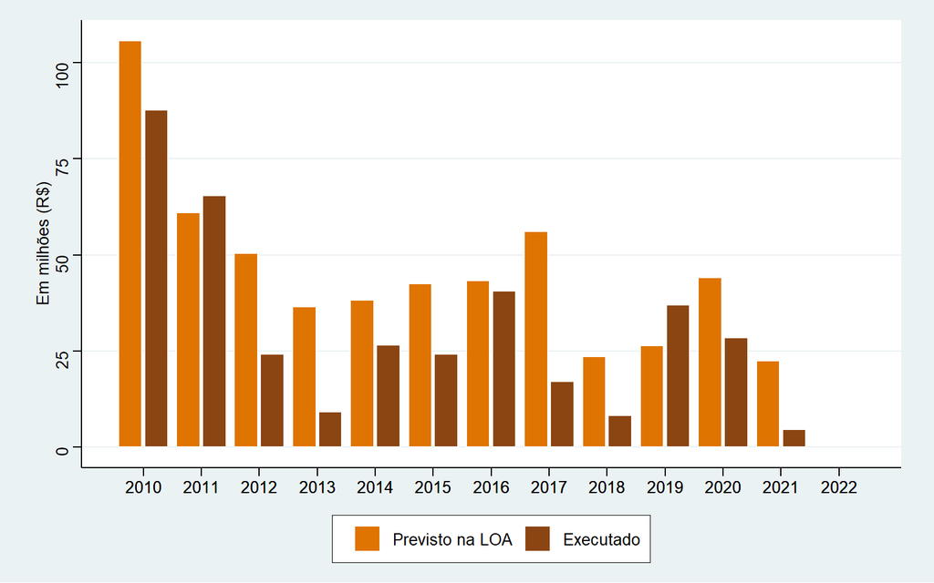

| ANO | PREVISTO NA LOA | EXECUTADO | LOA NOMINAL | EXECUTADO NOMINAL | % EXECUTADO |
| --- | --- | --- | --- | --- | --- |
| 2010 | R$ 105.759.538,30 | R$ 87.685.233,59 | R$ 57.392.997,00 | R$ 47.584.534,02 | 82.91 |
| 2011 | R$ 60.956.601,82 | R$ 65.378.785,04 | R$ 35.034.159,00 | R$ 37.575.761,80 | 107.25 |
| 2012 | R$ 50.453.763,16 | R$ 24.131.224,22 | R$ 30.883.591,00 | R$ 14.771.125,33 | 47.83 |
| 2013 | R$ 36.554.157,85 | R$ 9.141.402,35 | R$ 23.681.820,00 | R$ 5.922.309,74 | 25.01 |
| 2014 | R$ 38.200.735,48 | R$ 26.632.686,24 | R$ 26.211.374,00 | R$ 18.273.975,38 | 69.72 |
| 2015 | R$ 42.492.448,04 | R$ 24.203.718,59 | R$ 31.024.296,00 | R$ 17.671.453,74 | 56.96 |
| 2016 | R$ 43.291.378,13 | R$ 40.565.456,55 | R$ 34.981.094,00 | R$ 32.778.444,81 | 93.70 |
| 2017 | R$ 56.142.160,38 | R$ 17.159.431,61 | R$ 48.217.566,00 | R$ 14.737.338,58 | 30.56 |
| 2018 | R$ 23.494.439,98 | R$ 8.304.041,28 | R$ 20.772.881,00 | R$ 7.342.114,20 | 35.34 |
| 2019 | R$ 26.416.804,01 | R$ 36.969.277,50 | R$ 24.231.568,00 | R$ 33.911.125,71 | 139.95 |
| 2020 | R$ 44.085.708,93 | R$ 28.500.352,00 | R$ 42.180.235,00 | R$ 27.268.508,87 | 64.65 |
| 2021 | R$ 22.502.512,00 | R$ 4.650.777,59 | R$ 22.502.512,00 | R$ 4.650.777,59 | 20.67 |

**Valor previsto no PPA para 2022:** R$ 10.597.507,00

**Percentual de gasto em relação ao total das despesas:**

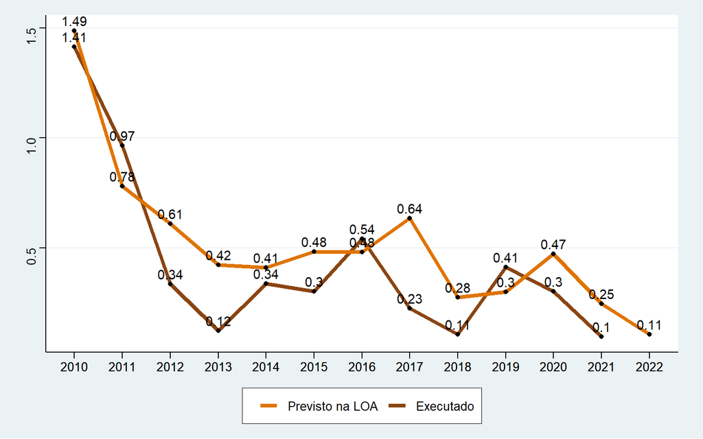

## 1.23 ENCARGOS ESPECIAIS:

**Função:** ENCARGOS ESPECIAIS

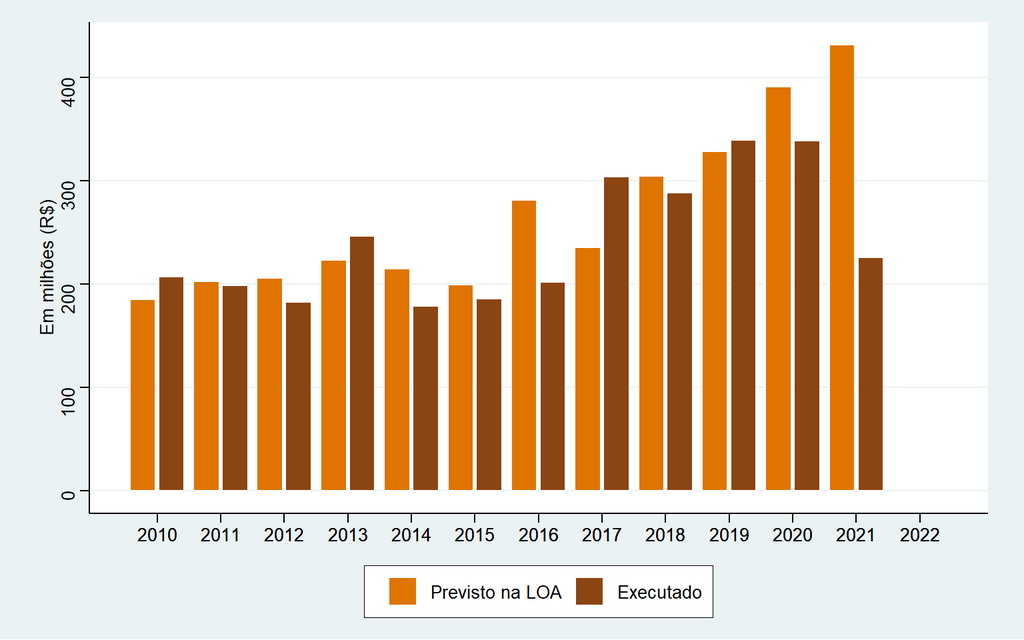

| ANO | PREVISTO NA LOA | EXECUTADO | LOA NOMINAL | EXECUTADO NOMINAL | % EXECUTADO |
| --- | --- | --- | --- | --- | --- |
| 2010 | R$ 184.965.734,04 | R$ 207.389.227,80 | R$ 100.376.174,00 | R$ 112.544.830,66 | 112.12 |
| 2011 | R$ 202.607.665,04 | R$ 198.850.755,54 | R$ 116.446.602,00 | R$ 114.287.358,20 | 98.15 |
| 2012 | R$ 206.125.652,24 | R$ 182.550.947,62 | R$ 126.172.954,00 | R$ 111.742.483,61 | 88.56 |
| 2013 | R$ 223.467.590,18 | R$ 246.572.643,61 | R$ 144.774.755,00 | R$ 159.743.495,87 | 110.34 |
| 2014 | R$ 214.830.789,31 | R$ 178.513.628,86 | R$ 147.405.805,00 | R$ 122.486.843,02 | 83.09 |
| 2015 | R$ 199.508.059,43 | R$ 185.670.608,34 | R$ 145.663.462,00 | R$ 135.560.556,70 | 93.06 |
| 2016 | R$ 281.156.204,30 | R$ 201.782.106,82 | R$ 227.184.997,00 | R$ 163.047.681,79 | 71.77 |
| 2017 | R$ 235.228.623,34 | R$ 304.120.036,45 | R$ 202.025.565,00 | R$ 261.192.797,54 | 129.29 |
| 2018 | R$ 304.508.917,02 | R$ 288.242.774,44 | R$ 269.235.083,00 | R$ 254.853.184,79 | 94.66 |
| 2019 | R$ 328.270.821,34 | R$ 338.965.124,74 | R$ 301.115.787,00 | R$ 310.925.442,25 | 103.26 |
| 2020 | R$ 390.766.642,40 | R$ 338.633.751,21 | R$ 373.876.914,00 | R$ 323.997.312,31 | 86.66 |
| 2021 | R$ 431.727.221,00 | R$ 226.091.315,90 | R$ 431.727.221,00 | R$ 226.091.315,90 | 52.37 |

**Valor previsto no PPA para 2022:** R$ 454.403.099,00

**Percentual de gasto em relação ao total das despesas:**

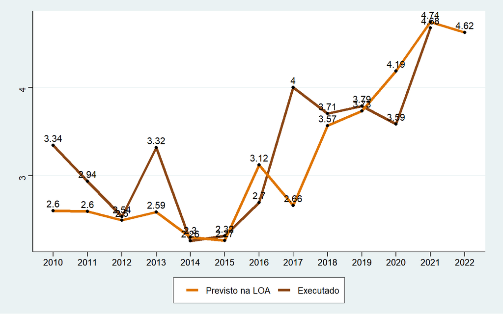

## 1.24 RESERVA DE CONTINGÊNCIA:

**Função:** RESERVA DE CONTINGENCIA

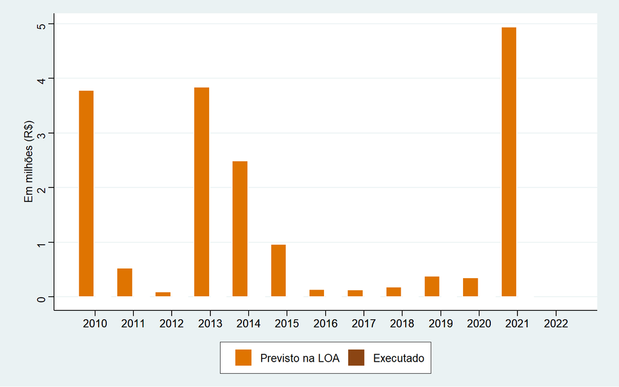

| ANO | PREVISTO NA LOA | EXECUTADO | LOA NOMINAL | EXECUTADO NOMINAL | % EXECUTADO |
| --- | --- | --- | --- | --- | --- |
| 2010 | R$ 3.777.587,25 | R$ 0,00 | R$ 2.050.000,00 | R$ 0,00 | 0 |
| 2011 | R$ 527.195,48 | R$ 0,00 | R$ 303.000,00 | R$ 0,00 | 0 |
| 2012 | R$ 87.401,63 | R$ 0,00 | R$ 53.500,00 | R$ 0,00 | 0 |
| 2013 | R$ 3.837.462,49 | R$ 0,00 | R$ 2.486.122,00 | R$ 0,00 | 0 |
| 2014 | R$ 2.490.073,53 | R$ 0,00 | R$ 1.708.560,00 | R$ 0,00 | 0 |
| 2015 | R$ 964.340,91 | R$ 0,00 | R$ 704.078,00 | R$ 0,00 | 0 |
| 2016 | R$ 136.132,15 | R$ 0,00 | R$ 110.000,00 | R$ 0,00 | 0 |
| 2017 | R$ 125.749,88 | R$ 0,00 | R$ 108.000,00 | R$ 0,00 | 0 |
| 2018 | R$ 178.568,04 | R$ 0,00 | R$ 157.883,00 | R$ 0,00 | 0 |
| 2019 | R$ 378.292,94 | R$ 0,00 | R$ 347.000,00 | R$ 0,00 | 0 |
| 2020 | R$ 346.997,96 | R$ 0,00 | R$ 332.000,00 | R$ 0,00 | 0 |
| 2021 | R$ 4.941.000,00 | R$ 0,00 | R$ 4.941.000,00 | R$ 0,00 | 0 |

**Valor previsto no PPA para 2022:** R$ 30.000.000,00

**Percentual de gasto em relação ao total das despesas:**

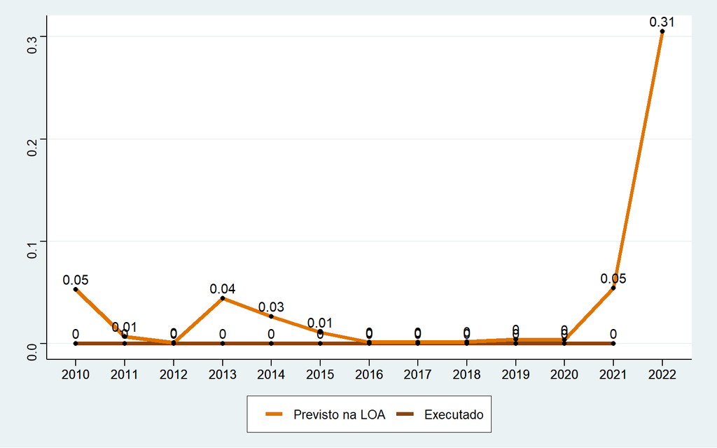

## 1.25 Fontes de dados

Portal da Transparência - Fortaleza-Ce